# Lab_#3_Response_Jack_Tan

JACKTANSNAKE

2021/2/9

Data description: UNMissions.csv has data on 54 United Nations (UN) Peacekeeping Missions from 1948 to 2001. For each mission, the following variables were recorded:

`Name`: An identifier label for the mission

`Duration`: Length of the mission in months

`Censored`: 0=exact (mission had ended) ; 1=censored (mission had not ended)

`CivilWar`: Was the mission in response to a civil war? (0=no ; 1=yes)

`InterState`: Was the mission in response to an interstate conflict? (0=no ; 1=yes)

`Troops`: Number of troops deployed during mission

`Expend`: Amount spent on mission (U.S. dollars)

`Deaths`: Number of recorded deaths during mission

`Area`: Size of region for which mission was deployed (in square-miles, I think)

`Borders`: Number of borders present in region where mission was deployed

`Note`: For some missions, both CivilWar and InterState are 0. These missions are said to be in response to an “internationalized civil war” (civil wars involving more than 1 government).

Reading the data into R and loading survival package: Type the following commands into your R Markdown file:

```r
UNMissions = read.csv( "https://www.macalester.edu/~addona/UNMissions.csv")
library(survival)
library(survminer)
library(tidyverse)
UNMissions <- UNMissions %>%
  mutate(Status = ifelse(Censored == 0, 1, 0))
```

1. Fit and graph the Kaplan-Meier curve (including its confidence interval) for the durations of the peacekeeping missions. In the survfit command, specify conf.type = ‘plain’ (this makes R use Greenwood’s formula to find the confidence intervals).

```r
KM <- survfit(Surv(Duration, Status) ~ 1 , data = UNMissions)
```

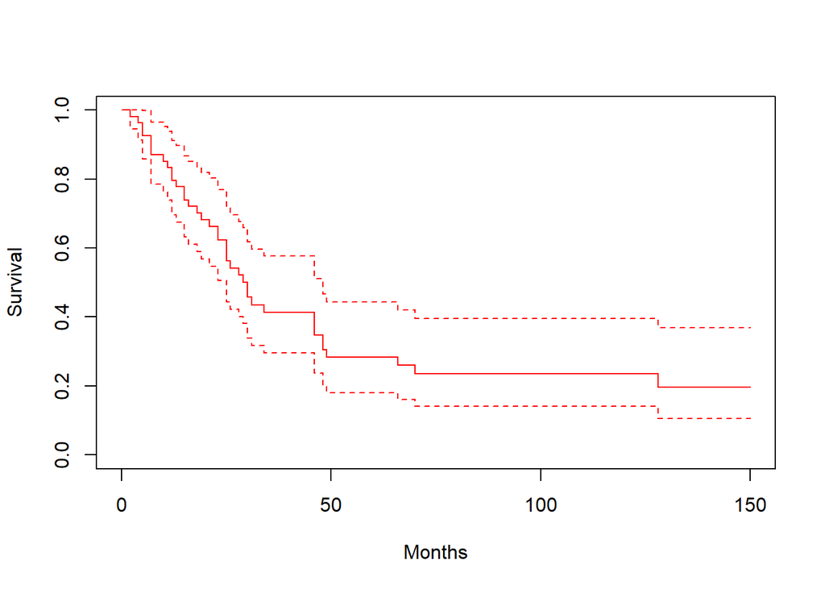

```r
plot(KM, conf.type = "plain", col = c("red"), xlab="Months", ylab="Survival", xlim = c(0, 150))
```

2. Find a point and interval estimate for the 40-month survival probability using the summary function on your Kaplan-Meier object.

```r
summary(KM)
```

```
## Call: survfit(formula = Surv(Duration, Status) ~ 1, data = UNMissions)
##
##  time n.risk n.event survival std.err lower 95% CI upper 95% CI
##     2     54       1    0.981  0.0183        0.946        1.000
##     4     53       1    0.963  0.0257        0.914        1.000
##     5     52       2    0.926  0.0356        0.859        0.998
##     7     50       3    0.870  0.0457        0.785        0.965
##    10     47       1    0.852  0.0483        0.762        0.952
##    11     46       1    0.833  0.0507        0.740        0.939
##    12     45       2    0.796  0.0548        0.696        0.911
##    13     43       1    0.778  0.0566        0.674        0.897
##    15     41       2    0.740  0.0598        0.631        0.867
##    16     39       1    0.721  0.0612        0.610        0.851
##    18     37       1    0.701  0.0626        0.589        0.835
##    19     36       1    0.682  0.0638        0.568        0.819
##    21     35       1    0.662  0.0649        0.547        0.803
##    23     34       2    0.623  0.0667        0.506        0.769
##    25     31       3    0.563  0.0687        0.443        0.715
##    26     27       1    0.542  0.0693        0.422        0.697
##    28     26       1    0.521  0.0697        0.401        0.678
##    29     25       1    0.501  0.0699        0.381        0.658
##    30     23       2    0.457  0.0703        0.338        0.618
##    31     21       1    0.435  0.0702        0.317        0.597
##    34     20       1    0.413  0.0700        0.297        0.576
##    46     19       3    0.348  0.0684        0.237        0.512
##    48     16       2    0.305  0.0664        0.199        0.467
##    49     14       1    0.283  0.0651        0.180        0.444
##    66     12       1    0.259  0.0638        0.160        0.420
##    70     11       1    0.236  0.0622        0.141        0.395
##   128      6       1    0.196  0.0630        0.105        0.369
```

0.413, [0.297, 0.576]

3. Find a point and interval estimate for when S(k) = 0.75 on the Duration distribution.